# TB Nanostring Analysis

W. Evan Johnson

2024-05-21

## Additional practice: TB Nanostring Analysis

The `TBnanostring.rds` dataset contains gene expression measurements in the blood for 107 TB-related genes for 179 patients with either active tuberculosis infection (TB) or latent TB infection (LTBI) from one of [Dr. Johnson’s publications](https://pubmed.ncbi.nlm.nih.gov/35015839/). When you Load these data into R ( `TBnanostring <- readRDS("TBnanostring.rds")`) the TB status is found in the first column of the data frame, followed by the genes in the subsequent columns. The rows represent each individual patient.

Here is a UMAP clustering of the dataset, and plot the result using `ggplot`. The points are colored based on TB status.

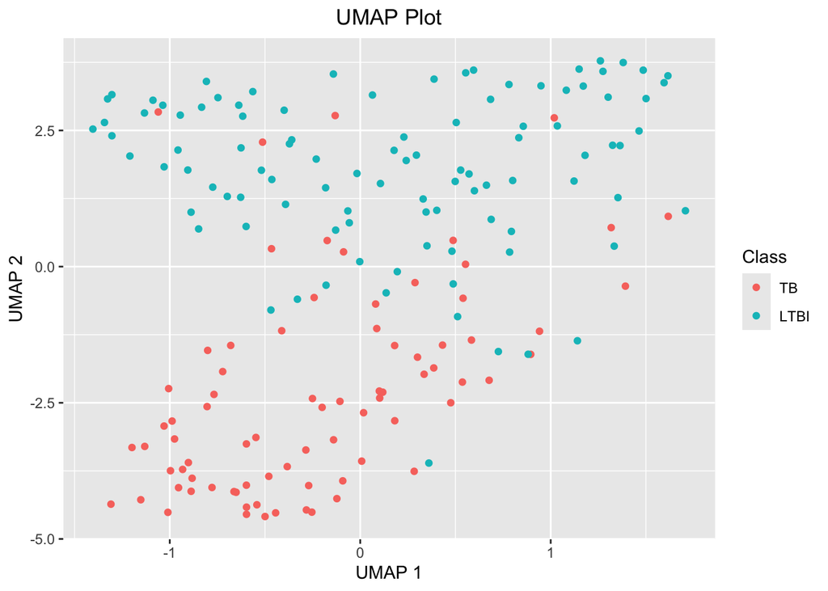

Now, using the `caret::train()` function, apply the following machine learning methods to make a predictive biomarker to distinguish between the TB and control samples, use the `caret` package and cross validation to find the “finalModel” parameters to for each method. Provide any relevant/informative plots with your results.

1. Split the dataset into “training” and “testing” sets using a 70/30 partition (use `set.seed(0)` and the `caret::createDataPartition`).

```r
set.seed(0)
training_indexs <- createDataPartition(TBnanostring$TB_Status, p = .7, list = F)
training <- TBnanostring[training_indexs, ]
testing  <- TBnanostring[-training_indexs, ]
```

2. Apply a Support Vector Machine to these data (try linear, radial, and polynomial kernels).

```r
svm_linear <- train(TB_Status ~ . , data=training, method = "svmLinear")
svm_linear$finalModel
```

```
## Support Vector Machine object of class "ksvm"
##
## SV type: C-svc  (classification)
##  parameter : cost C = 1
##
## Linear (vanilla) kernel function.
##
## Number of Support Vectors : 47
##
## Objective Function Value : -1.3599
## Training error : 0
```

```r
svm_radial <- train(TB_Status ~ . , data=training, method = "svmRadial")
svm_radial$finalModel
```

```
## Support Vector Machine object of class "ksvm"
##
## SV type: C-svc  (classification)
##  parameter : cost C = 1
##
## Gaussian Radial Basis kernel function.
##  Hyperparameter : sigma =  0.0076658210288376
##
## Number of Support Vectors : 67
##
## Objective Function Value : -27.6242
## Training error : 0.02381
```

```r
svm_poly <- train(TB_Status ~ . , data=training, method = "svmPoly")
svm_poly$finalModel
```

```
## Support Vector Machine object of class "ksvm"
##
## SV type: C-svc  (classification)
##  parameter : cost C = 0.25
##
## Polynomial kernel function.
##  Hyperparameters : degree =  1  scale =  0.01  offset =  1
##
## Number of Support Vectors : 55
##
## Objective Function Value : -10.0226
## Training error : 0.087302
```

3. Apply a Random Forest Model to these data.

```r
rf <- train(TB_Status ~ ., data=training, method ="rf")
rf$finalModel
```

```
##
## Call:
##  randomForest(x = x, y = y, mtry = param$mtry)
##                Type of random forest: classification
##                      Number of trees: 500
## No. of variables tried at each split: 2
##
##         OOB estimate of  error rate: 13.49%
## Confusion matrix:
##      TB LTBI class.error
## TB   44   12  0.21428571
## LTBI  5   65  0.07142857
```

4. Apply a Feedforward Perceptron Neural Network to these data.

```r
nn <- train(TB_Status ~ ., data=training, method ="nnet", trace=F)
nn$finalModel
```

```
## a 107-1-1 network with 110 weights
## inputs: AGAP9 AIRE ANKRD22 APOL1 APOL6 ATP1A1 BATF2 BCL6 BLK C16orf7 C1QB C1QC C4ORF18 C5 CCDC14 CCDC78 CCR6 CD1C CD79A CD79B CIRBP CTSA CXCR5 CXorf40B CYP4F3 DARS2 DERA DUSP3 ENO3 ETV7 EXOC2 FAM20A FCER1G FCGR1A FCGR1B FLVCR2 FUT4 GAS6 GBP1 GBP2 GBP4 GBP5 GBP6 GNG7 GSTA4 GYG1 HK3 HM13 ID3 IFI44L…
## output(s): .outcome
## options were - entropy fitting  decay=0.1
```

5. Compare the overall accuracy of the prediction methods for each of the machine learning tools in the previous problem. Which one performs the best?

```r
ps <- predict(svm_linear, testing); svm_linear_accuracy <- confusionMatrix(ps, testing$TB_Status)$overall["Accuracy"]
ps <- predict(svm_radial, testing); svm_radial_accuracy <- confusionMatrix(ps, testing$TB_Status)$overall["Accuracy"]
ps <- predict(svm_poly, testing); svm_poly_accuracy <- confusionMatrix(ps, testing$TB_Status)$overall["Accuracy"]
ps <- predict(rf, testing); rf_accuracy <- confusionMatrix(ps, testing$TB_Status)$overall["Accuracy"]
ps <- predict(nn, testing); nn_accuracy <- confusionMatrix(ps, testing$TB_Status)$overall["Accuracy"]

c(SVM_LIN = svm_linear_accuracy, SVM_RAD = svm_radial_accuracy, SVM_POLY=svm_poly_accuracy, RF = rf_accuracy, NNet = nn_accuracy)
```

```
##  SVM_LIN.Accuracy  SVM_RAD.Accuracy SVM_POLY.Accuracy       RF.Accuracy
##         0.8113208         0.8679245         0.8679245         0.8679245
##     NNet.Accuracy
##         0.8490566
```